# 2026-04-13_hw07

Chris

2026-04-13

# 1 Read the Data

```r
library(tidyverse)
library(lmerTest)
df_polite <- read_csv("data/HW7_politeness_data.csv") |>
  janitor::clean_names() |>
  mutate(
    gender = factor(gender, levels = c("M", "F")),
    subject = factor(subject),
    scenario = factor(scenario),
    attitude = factor(attitude, levels = c("inf", "pol")),
    frequency = as.numeric(frequency)
  )
```

# 2 Question a

## 2.1 Gender & Pitch

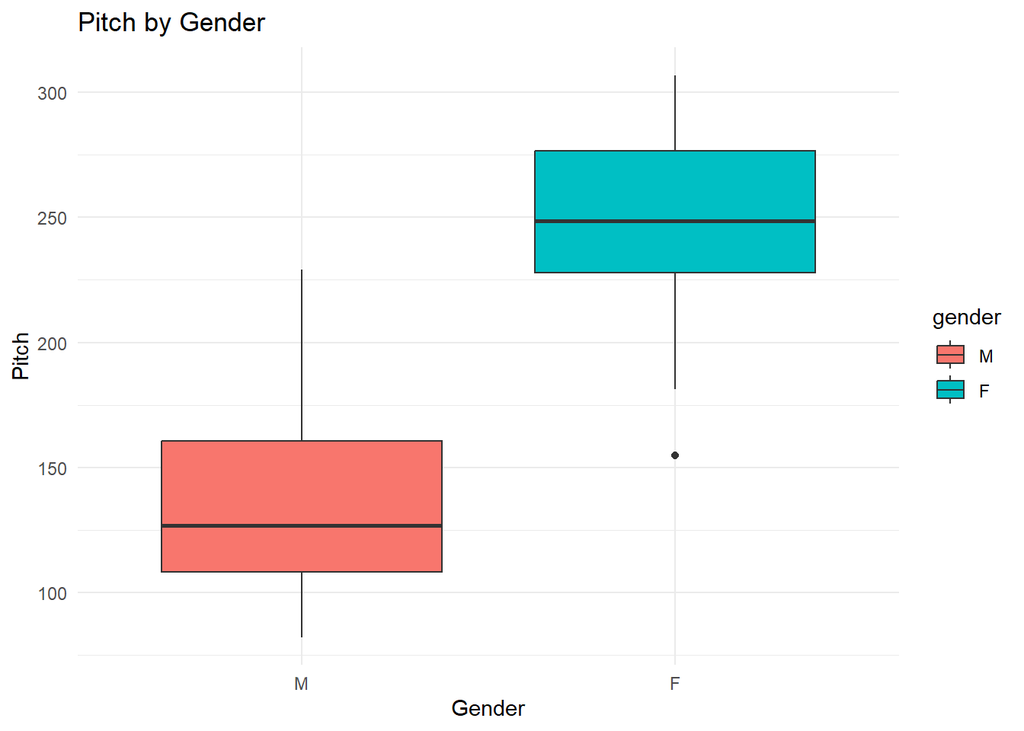

```r
fig_1 <- df_polite |>
  ggplot(aes(x = gender, y = frequency)) + geom_boxplot(aes(fill = gender)) +
  labs(
    x = "Gender",
    y = "Pitch",
    title = "Pitch by Gender"
  ) + theme_minimal()

fig_1
```

```r
ggsave("plots/2026-04-13_fig1-boxplot_gender-pitch.png", fig_1)
```

## 2.2 Attitude & Pitch

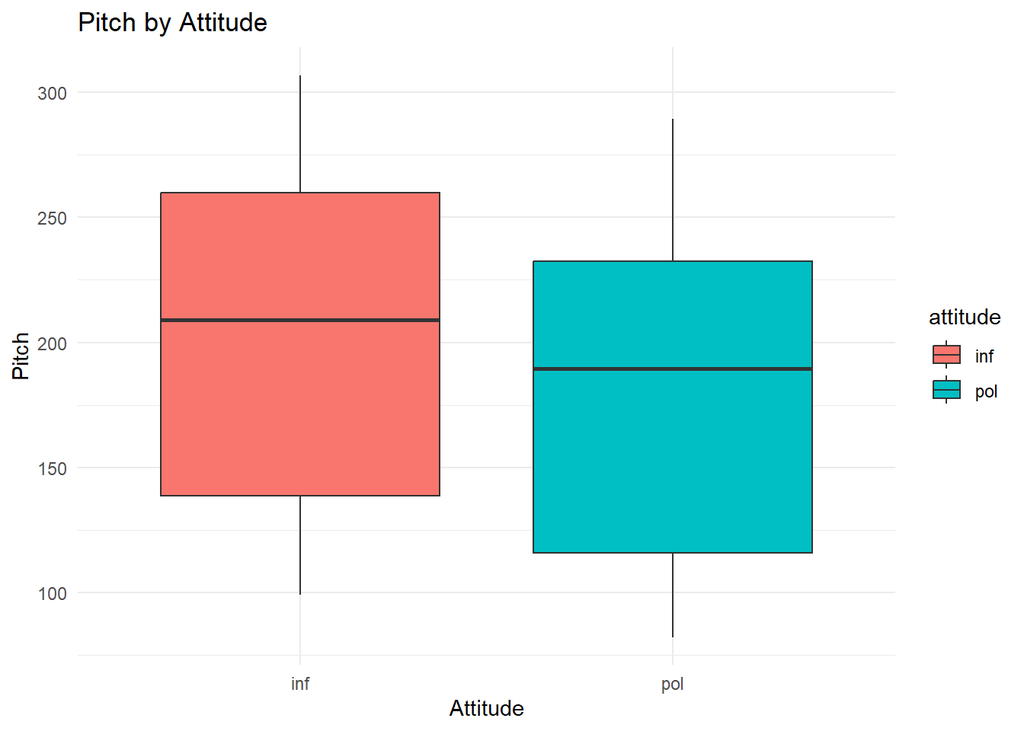

```r
fig_2 <- df_polite |>
  ggplot(aes(x = attitude, y = frequency)) + geom_boxplot(aes(fill = attitude)) +
  labs(
    x = "Attitude",
    y = "Pitch",
    title = "Pitch by Attitude"
  ) + theme_minimal()

fig_2
```

```r
ggsave("plots/2026-04-13_fig2-boxplot_attitude-pitch.png", fig_2)
```

## 2.3 Pitch by Gender & Attitude

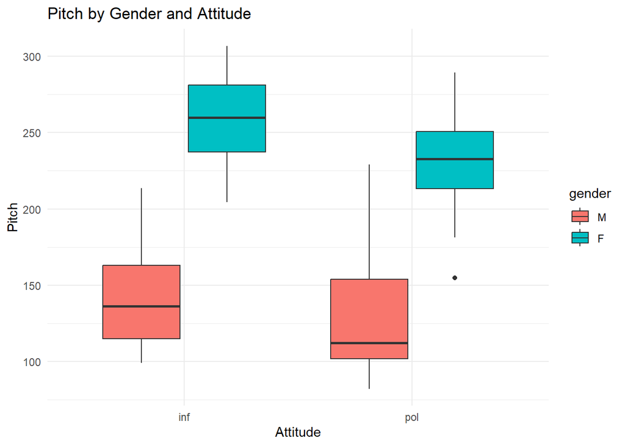

```r
fig_3 <- df_polite |>
  ggplot(aes(x = attitude, y = frequency, fill = gender)) + geom_boxplot() +
  labs(
    x = "Attitude",
    y = "Pitch",
    title = "Pitch by Gender and Attitude"
  ) + theme_minimal()

fig_3
```

```r
ggsave("plots/2026-04-13_fig3-boxplot_gender-attitude-pitch.png", fig_3)
```

Based on the data and the combined plot, females have higher median frequency than males, regardless of attitude. Within males, the informal group also has a higher median than the formal group.

# 3 Question b

## 3.1 Fit the Model

```r
fit1 <- lmer(frequency ~ gender + attitude + (1 | subject), data = df_polite, REML = FALSE)

summary(fit1)
```

```
## Linear mixed model fit by maximum likelihood . t-tests use Satterthwaite's
##   method [lmerModLmerTest]
## Formula: frequency ~ gender + attitude + (1 | subject)
##    Data: df_polite
##
##       AIC       BIC    logLik -2*log(L)  df.resid
##     825.6     837.8    -407.8     815.6        79
##
## Scaled residuals:
##     Min      1Q  Median      3Q     Max
## -2.3945 -0.5728 -0.2229  0.4872  3.3291
##
## Random effects:
##  Groups   Name        Variance Std.Dev.
##  subject  (Intercept) 379.4    19.48
##  Residual             836.8    28.93
## Number of obs: 84, groups:  subject, 6
##
## Fixed effects:
##             Estimate Std. Error      df t value Pr(>|t|)
## (Intercept)  148.189     12.504   6.842  11.851 8.25e-06 ***
## genderF      108.798     17.111   6.000   6.358  0.00071 ***
## attitudepol  -20.002      6.313  78.000  -3.169  0.00219 **
## ---
## Signif. codes:  0 '***' 0.001 '**' 0.01 '*' 0.05 '.' 0.1 ' ' 1
##
## Correlation of Fixed Effects:
##             (Intr) gendrF
## genderF     -0.684
## attitudepol -0.252  0.000
```

```r
# anova(fit1)
```

## 3.2 Covariance Matrix for Y_i

```r
vc1 <- VarCorr(fit1)

tau2   <- as.numeric(vc1$subject[1, 1])
sigma2 <- sigma(fit1)^2

V_i <- tau2 * matrix(1, 14, 14) + sigma2 * diag(14)
V_i
```

```
##            [,1]      [,2]      [,3]      [,4]      [,5]      [,6]      [,7]
##  [1,] 1216.2266  379.3897  379.3897  379.3897  379.3897  379.3897  379.3897
##  [2,]  379.3897 1216.2266  379.3897  379.3897  379.3897  379.3897  379.3897
##  [3,]  379.3897  379.3897 1216.2266  379.3897  379.3897  379.3897  379.3897
##  [4,]  379.3897  379.3897  379.3897 1216.2266  379.3897  379.3897  379.3897
##  [5,]  379.3897  379.3897  379.3897  379.3897 1216.2266  379.3897  379.3897
##  [6,]  379.3897  379.3897  379.3897  379.3897  379.3897 1216.2266  379.3897
##  [7,]  379.3897  379.3897  379.3897  379.3897  379.3897  379.3897 1216.2266
##  [8,]  379.3897  379.3897  379.3897  379.3897  379.3897  379.3897  379.3897
##  [9,]  379.3897  379.3897  379.3897  379.3897  379.3897  379.3897  379.3897
## [10,]  379.3897  379.3897  379.3897  379.3897  379.3897  379.3897  379.3897
## [11,]  379.3897  379.3897  379.3897  379.3897  379.3897  379.3897  379.3897
## [12,]  379.3897  379.3897  379.3897  379.3897  379.3897  379.3897  379.3897
## [13,]  379.3897  379.3897  379.3897  379.3897  379.3897  379.3897  379.3897
## [14,]  379.3897  379.3897  379.3897  379.3897  379.3897  379.3897  379.3897
##            [,8]      [,9]     [,10]     [,11]     [,12]     [,13]     [,14]
##  [1,]  379.3897  379.3897  379.3897  379.3897  379.3897  379.3897  379.3897
##  [2,]  379.3897  379.3897  379.3897  379.3897  379.3897  379.3897  379.3897
##  [3,]  379.3897  379.3897  379.3897  379.3897  379.3897  379.3897  379.3897
##  [4,]  379.3897  379.3897  379.3897  379.3897  379.3897  379.3897  379.3897
##  [5,]  379.3897  379.3897  379.3897  379.3897  379.3897  379.3897  379.3897
##  [6,]  379.3897  379.3897  379.3897  379.3897  379.3897  379.3897  379.3897
##  [7,]  379.3897  379.3897  379.3897  379.3897  379.3897  379.3897  379.3897
##  [8,] 1216.2266  379.3897  379.3897  379.3897  379.3897  379.3897  379.3897
##  [9,]  379.3897 1216.2266  379.3897  379.3897  379.3897  379.3897  379.3897
## [10,]  379.3897  379.3897 1216.2266  379.3897  379.3897  379.3897  379.3897
## [11,]  379.3897  379.3897  379.3897 1216.2266  379.3897  379.3897  379.3897
## [12,]  379.3897  379.3897  379.3897  379.3897 1216.2266  379.3897  379.3897
## [13,]  379.3897  379.3897  379.3897  379.3897  379.3897 1216.2266  379.3897
## [14,]  379.3897  379.3897  379.3897  379.3897  379.3897  379.3897 1216.2266
```

We fit the random-intercept mixed-effects model
$$Y_{ij} = \beta_0 + \beta_1 \,\text{gender}_i + \beta_2
\,\text{attitude}_{ij} + b_i + \varepsilon_{ij},$$
where
$$b_i \sim N(0,\tau^2), \qquad \varepsilon_{ij} \sim N(0,\sigma^2),$$
and $b_i$ and $\varepsilon_{ij}$ are independent.

For subject $i$, let
$$Y_i = (Y_{i1}, Y_{i2}, \dots, Y_{i n_i})^T.$$
Then the model can be written in matrix form as
$$Y_i = X_i \beta + Z_i b_i + \varepsilon_i,$$
where $Z_i = \mathbf{1}_{n_i}$ for the random-intercept model. Therefore,
$$\mathrm{Var}(Y_i) = Z_i \,\mathrm{Var}(b_i)\, Z_i^T +
\mathrm{Var}(\varepsilon_i)
= \tau^2 J_{n_i} + \sigma^2 I_{n_i}.$$

Since each subject has 14 observations in this dataset,
$$\mathrm{Var}(Y_i) = \tau^2 J_{14} + \sigma^2 I_{14}.$$

Equivalently, the diagonal entries are
$$\mathrm{Var}(Y_{ij}) = \tau^2 + \sigma^2,$$
and for $j \neq k$, the off-diagonal entries are
$$\mathrm{Cov}(Y_{ij}, Y_{ik}) = \tau^2.$$

The covariance matrix for the estimates of the fixed effects is
$$\mathrm{Var}(\hat{\beta}) = (X^T V^{-1} X)^{-1},$$
which is a $3 \times 3$ matrix corresponding to the intercept, gender, and attitude effects.

The conditional residuals are
$$\hat{e}_{ij} = Y_{ij} - \hat{\beta}_0 - \hat{\beta}_1 \,\text{gender}_i
- \hat{\beta}_2 \,\text{attitude}_{ij} - \hat{b}_i.$$

## 3.3 Covariance Matrix for Fixed Effects

```r
vcov(fit1)
```

```
## 3 x 3 Matrix of class "dpoMatrix"
##             (Intercept)       genderF   attitudepol
## (Intercept)   156.35028 -1.463879e+02 -1.992469e+01
## genderF      -146.38793  2.927759e+02 -4.953090e-14
## attitudepol   -19.92469 -4.953090e-14  3.984938e+01
```

## 3.4 Subject-Specific Intercepts

```r
ranef(fit1)$subject # random intercept
```

```
##    (Intercept)
## F1  -12.915173
## F2    9.675581
## F3    3.239592
## M3   26.599621
## M4    4.508689
## M7  -31.108310
```

```r
coef(fit1)$subject # fixed intercept + random intercept
```

```
##    (Intercept)  genderF attitudepol
## F1    135.2741 108.7976   -20.00238
## F2    157.8649 108.7976   -20.00238
## F3    151.4289 108.7976   -20.00238
## M3    174.7889 108.7976   -20.00238
## M4    152.6980 108.7976   -20.00238
## M7    117.0810 108.7976   -20.00238
```

The BLUPs of the subject-specific random intercepts are the predicted random effects $\hat{b_i}$, obtained from `ranef(fit1)`. If one wants the full subject-specific intercepts, they are $\hat{\beta_0} + \hat{b_i}$, obtainable from `coef(fit1)`

## 3.5 Residuals

```r
resid(fit1)
```

```
##            1            2            3            4            5            6
## -10.76935059 -39.57173154  61.03064941  15.62826846 -20.16935059  42.82826846
##            7            8            9           10           11           12
##  26.73064941  32.72826846   7.83064941   8.32826846 -42.86935059 -13.37173154
##           13           14           15           16           17           18
## -27.57173154 -69.26935059 -10.52411576 -22.92649671  -3.42411576  -9.22649671
##           19           20           21           22           23           24
##  26.77588424   5.77350329  35.17588424  46.57350329  -7.62411576  -7.72649671
##           25           26           27           28           29           30
## -13.72411576  18.57350329   4.17350329 -54.72411576 -21.99559400 -29.09797495
##           31           32           33           34           35           36
##  96.30440600 -37.79797495 -20.49559400  60.90202505  60.70440600  10.20202505
##           37           38           39           40           41           42
## -30.89559400 -25.79797495 -22.69559400 -16.49797495  -6.69797495  -6.19559400
##           43           44           45           46           47           48
## -10.97859455 -17.98097550 -14.87859455 -12.78097550 -11.17859455  -6.88097550
##           49           50           51           52           53           54
##   0.02140545   2.91902450  -3.37859455 -14.18097550  11.72140545  -8.88097550
##           55           56           57           58           59           60
##   7.31902450  10.52140545 -13.96010509 -35.36248604  -0.36010509  -6.96248604
##           61           62           63           64           65           66
##  42.73989491  35.13751396  -3.46010509  29.53751396  31.03989491  27.53751396
##           67           68           69           70           71           72
## -38.66010509 -40.76248604  14.33751396 -19.46010509  -0.98652574  14.01109331
##           73           74           75           76           77           78
## -12.38652574  24.91109331   5.41347426  11.31109331  52.71347426  16.11109331
##           79           80           81           82           83           84
##   5.91347426 -18.28890669  -8.08652574 -16.78890669 -13.68890669  -1.48652574
```

# 4 Question c

## 4.1 Fit the Model

```r
fit2 <- lmer(frequency ~ gender * attitude + (1 | subject), data = df_polite, REML = FALSE)
summary(fit2)
```

```
## Linear mixed model fit by maximum likelihood . t-tests use Satterthwaite's
##   method [lmerModLmerTest]
## Formula: frequency ~ gender * attitude + (1 | subject)
##    Data: df_polite
##
##       AIC       BIC    logLik -2*log(L)  df.resid
##     826.3     840.8    -407.1     814.3        78
##
## Scaled residuals:
##     Min      1Q  Median      3Q     Max
## -2.2856 -0.5246 -0.1719  0.4929  3.2294
##
## Random effects:
##  Groups   Name        Variance Std.Dev.
##  subject  (Intercept) 380.4    19.50
##  Residual             822.1    28.67
## Number of obs: 84, groups:  subject, 6
##
## Fixed effects:
##                     Estimate Std. Error      df t value Pr(>|t|)
## (Intercept)          144.490     12.883   7.701  11.216 4.83e-06 ***
## genderF              116.195     18.219   7.701   6.378 0.000252 ***
## attitudepol          -12.605      8.848  78.000  -1.425 0.158287
## genderF:attitudepol  -14.795     12.514  78.000  -1.182 0.240667
## ---
## Signif. codes:  0 '***' 0.001 '**' 0.01 '*' 0.05 '.' 0.1 ' ' 1
##
## Correlation of Fixed Effects:
##             (Intr) gendrF atttdp
## genderF     -0.707
## attitudepol -0.343  0.243
## gndrF:tttdp  0.243 -0.343 -0.707
```

```r
# anova(fit2)
```

## 4.2 LRT

```r
anova(fit1, fit2)
```

```
## Data: df_polite
## Models:
## fit1: frequency ~ gender + attitude + (1 | subject)
## fit2: frequency ~ gender * attitude + (1 | subject)
##      npar    AIC    BIC  logLik -2*log(L)  Chisq Df Pr(>Chisq)
## fit1    5 825.64 837.79 -407.82    815.64
## fit2    6 826.25 840.84 -407.13    814.25 1.3855  1     0.2392
```

We compared the model with main effects only and the model including the `gender $\times$ attitude` interaction using a likelihood ratio test. The test gave $\chi^2 = 1.3855$ with 1 degree of freedom and p = 0.2392 > 0.05. Since the p-value is greater than 0.05, there is no significant evidence that the interaction term is associated with pitch. Therefore, the simpler model without the interaction term is preferred.

# 5 Question d

The model is
$$Y_{ijk} = \beta_0 + \beta_1
gender_i + \beta_2 attitude_{ijk} + b_i + c_j +
\epsilon_{ijk}$$
.
$b_i$ is the random intercept of `subject`, $c_j$ is the random intercept of `scenario` and $\epsilon_{ijk}$ is the residual error. We assume that $b_i \sim N(0, \tau_{sub}^2)$, $c_j \sim N(0, \tau_{scen}^2)$, $\epsilon_{ijk} \sim N(0, \sigma^2)$ and these three terms are mutually independent.

## 5.1 Fit the Model

```r
fit3 <- lme4::lmer(frequency ~ gender + attitude + (1 | subject) + (1 | scenario), data = df_polite, REML = FALSE)
summary(fit3)
```

```
## Linear mixed model fit by maximum likelihood  ['lmerMod']
## Formula: frequency ~ gender + attitude + (1 | subject) + (1 | scenario)
##    Data: df_polite
##
##       AIC       BIC    logLik -2*log(L)  df.resid
##     815.7     830.3    -401.9     803.7        78
##
## Scaled residuals:
##     Min      1Q  Median      3Q     Max
## -2.3054 -0.6456 -0.0917  0.5210  3.5644
##
## Random effects:
##  Groups   Name        Variance Std.Dev.
##  scenario (Intercept) 209.8    14.48
##  subject  (Intercept) 415.7    20.39
##  Residual             629.6    25.09
## Number of obs: 84, groups:  scenario, 7; subject, 6
##
## Fixed effects:
##             Estimate Std. Error t value
## (Intercept)  148.189     13.821  10.722
## genderF      108.798     17.525   6.208
## attitudepol  -20.002      5.475  -3.653
##
## Correlation of Fixed Effects:
##             (Intr) gendrF
## genderF     -0.634
## attitudepol -0.198  0.000
```

```r
# anova(fit3)
```

## 5.2 Covariance Matrix

```r
# extract variance components
vc3 <- VarCorr(fit3)

tau_subj2 <- as.numeric(vc3$subject[1, 1])
tau_scen2 <- as.numeric(vc3$scenario[1, 1])
sigma2    <- sigma(fit3)^2
```

```r
# choose one subject
subj_id <- levels(df_polite$subject)[1]
df_i <- subset(df_polite, subject == subj_id)
df_i <- df_i[order(df_i$scenario, df_i$attitude), ]
```

```r
# build matrices
n_i <- nrow(df_i)
J <- matrix(1, n_i, n_i)
A <- outer(df_i$scenario, df_i$scenario, "==") * 1
I <- diag(n_i)
```

```r
V_i <- tau_subj2 * J + tau_scen2 * A + sigma2 * I

V_i
```

```
##            [,1]      [,2]      [,3]      [,4]      [,5]      [,6]      [,7]
##  [1,] 1255.0578  625.5026  415.7183  415.7183  415.7183  415.7183  415.7183
##  [2,]  625.5026 1255.0578  415.7183  415.7183  415.7183  415.7183  415.7183
##  [3,]  415.7183  415.7183 1255.0578  625.5026  415.7183  415.7183  415.7183
##  [4,]  415.7183  415.7183  625.5026 1255.0578  415.7183  415.7183  415.7183
##  [5,]  415.7183  415.7183  415.7183  415.7183 1255.0578  625.5026  415.7183
##  [6,]  415.7183  415.7183  415.7183  415.7183  625.5026 1255.0578  415.7183
##  [7,]  415.7183  415.7183  415.7183  415.7183  415.7183  415.7183 1255.0578
##  [8,]  415.7183  415.7183  415.7183  415.7183  415.7183  415.7183  625.5026
##  [9,]  415.7183  415.7183  415.7183  415.7183  415.7183  415.7183  415.7183
## [10,]  415.7183  415.7183  415.7183  415.7183  415.7183  415.7183  415.7183
## [11,]  415.7183  415.7183  415.7183  415.7183  415.7183  415.7183  415.7183
## [12,]  415.7183  415.7183  415.7183  415.7183  415.7183  415.7183  415.7183
## [13,]  415.7183  415.7183  415.7183  415.7183  415.7183  415.7183  415.7183
## [14,]  415.7183  415.7183  415.7183  415.7183  415.7183  415.7183  415.7183
##            [,8]      [,9]     [,10]     [,11]     [,12]     [,13]     [,14]
##  [1,]  415.7183  415.7183  415.7183  415.7183  415.7183  415.7183  415.7183
##  [2,]  415.7183  415.7183  415.7183  415.7183  415.7183  415.7183  415.7183
##  [3,]  415.7183  415.7183  415.7183  415.7183  415.7183  415.7183  415.7183
##  [4,]  415.7183  415.7183  415.7183  415.7183  415.7183  415.7183  415.7183
##  [5,]  415.7183  415.7183  415.7183  415.7183  415.7183  415.7183  415.7183
##  [6,]  415.7183  415.7183  415.7183  415.7183  415.7183  415.7183  415.7183
##  [7,]  625.5026  415.7183  415.7183  415.7183  415.7183  415.7183  415.7183
##  [8,] 1255.0578  415.7183  415.7183  415.7183  415.7183  415.7183  415.7183
##  [9,]  415.7183 1255.0578  625.5026  415.7183  415.7183  415.7183  415.7183
## [10,]  415.7183  625.5026 1255.0578  415.7183  415.7183  415.7183  415.7183
## [11,]  415.7183  415.7183  415.7183 1255.0578  625.5026  415.7183  415.7183
## [12,]  415.7183  415.7183  415.7183  625.5026 1255.0578  415.7183  415.7183
## [13,]  415.7183  415.7183  415.7183  415.7183  415.7183 1255.0578  625.5026
## [14,]  415.7183  415.7183  415.7183  415.7183  415.7183  625.5026 1255.0578
```

- Under this model, the covariance matrix for $Y_i$ is the same across subjects, provided that each subject has the same number of observations and the same scenario structure. This is because the variance components $\tau_{sub}^2$, $\tau_{scen}^2$ and $\sigma^2$ are common to all subjects, and the indicator matrix for scenario membership is the same for each subject.
- For a fixed subject i, there are 14 observations in total, corresponding to 7 scenarios and 2 attitude conditions within each scenario. Let $Y_i$ denote the $14 \times 1$ response vector for subject i. Then the covariance matrix for $Y_i$ is
  $$Var(Y_i) = \tau_{sub}^2 J + \tau_{scen}^2 A_i +
  \sigma^2 I$$
  where J is a $14 \times 14$ matrix of ones, I is a $14 \times 14$ identity matrix and $A_i$ is the indicator matrix with entry 1 if two observations belong to the same scenario and 0 otherwise.
- More specifically, the covariance structure is:
  $$Var(Y_{ijk}) = \tau_{sub}^2 + \tau_{scen}^2 +
  \sigma^2$$
  $Cov(Y_{ijk}, Y_{ijb}) = \tau_{sub}^2 + \tau_{scen}^2$ if the subject and scenario are the same but attitude differs, $Cov(Y_{ijk}, Y_{iak}) = \tau_{sub}^2$ if the subject is the same but the scenario differs, and $Cov(Y_{ijk}, Y_{iab}) = \tau_{sub}^2$ if both scenario and attitude differ but the subject is the same.
- Thus, within the same subject, observations from the same scenario are more strongly correlated because they share both the subject effect and the scenario effect, whereas observations from different scenarios share only the subject effect.

## 5.3 Interpretation

The coefficient for the fixed effect term `attitude` represents the average difference in pitch between the polite (`pol`) and informal (`inf`) conditions, after adjusting for gender and accounting for random intercept variation across subjects and scenarios. In this model, the estimated coefficient is -20.002, which means that, on average, the pitch in the polite condition is about 20 units lower than in the informal condition, holding gender constant.